# Demographics Analysis

This notebook aims to analyze the demographics data from Harry Chapin Food Bank Nutrition Education program. We will focus on various aspects such as age, gender, ethnicity, and location.

```python
import pandas as pd
import matplotlib.pyplot as plt
import seaborn as sns
```

## Data Loading

First, let's load the data into a Pandas DataFrame. For the purpose of this analysis, I'll assume that the data is available in a CSV file named `Program-Activities-Export (33) (1).csv`.

```python
# Load the data into a Pandas DataFrame
# Note: Replace 'demographics_data.csv' with the actual path to your CSV file
df = pd.read_csv('Program-Activities-Export (33) (1).csv')
```

## Age Distribution Analysis

We will start by analyzing the age distribution of participants in the programs.

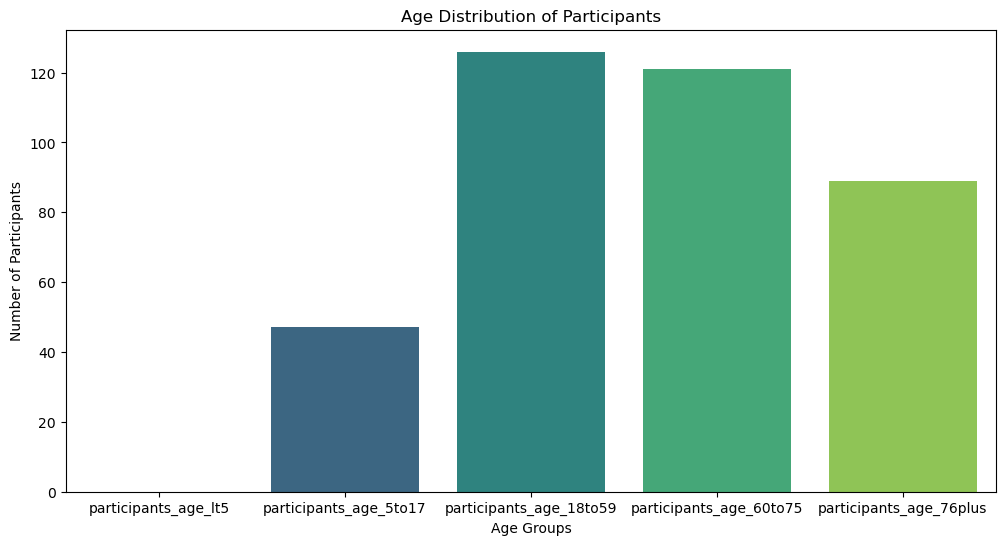

```python
# Age Distribution Analysis
age_columns = ['participants_age_lt5', 'participants_age_5to17', 'participants_age_18to59', 'participants_age_60to75', 'participants_age_76plus']
age_distribution = df[age_columns].sum()
plt.figure(figsize=(12, 6))
sns.barplot(x=age_distribution.index, y=age_distribution.values, palette='viridis')
plt.title('Age Distribution of Participants')
plt.xlabel('Age Groups')
plt.ylabel('Number of Participants')
plt.show()
```

## Race Distribution Analysis

Next, we will analyze the distribution of participants based on their race.

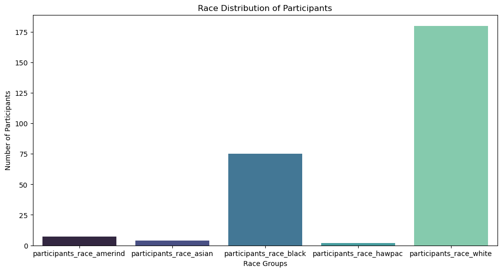

```python
# Race Distribution Analysis
race_columns = ['participants_race_amerind', 'participants_race_asian', 'participants_race_black', 'participants_race_hawpac', 'participants_race_white']
race_distribution = df[race_columns].sum()
plt.figure(figsize=(12, 6))
sns.barplot(x=race_distribution.index, y=race_distribution.values, palette='mako')
plt.title('Race Distribution of Participants')
plt.xlabel('Race Groups')
plt.ylabel('Number of Participants')
plt.show()
```

## Ethnicity Distribution Analysis

We will now examine the distribution of participants based on their ethnicity.

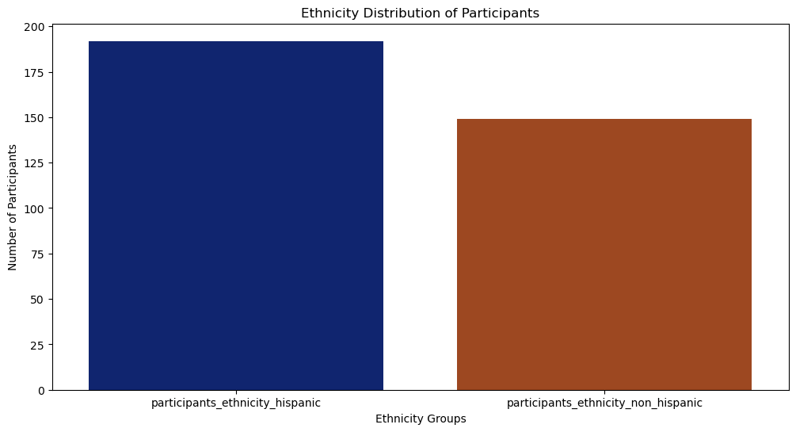

```python
# Ethnicity Distribution Analysis
ethnicity_columns = ['participants_ethnicity_hispanic', 'participants_ethnicity_non_hispanic']
ethnicity_distribution = df[ethnicity_columns].sum()
plt.figure(figsize=(12, 6))
sns.barplot(x=ethnicity_distribution.index, y=ethnicity_distribution.values, palette='dark')
plt.title('Ethnicity Distribution of Participants')
plt.xlabel('Ethnicity Groups')
plt.ylabel('Number of Participants')
plt.show()
```

## Direct Education County Distribution Analysis

We will analyze the distribution of programs across different counties.

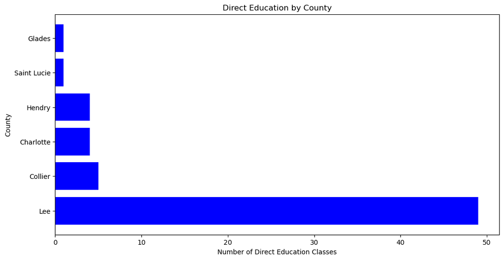

```python
# Analyzing the distribution of programs across different counties
county_distribution = df['site_county'].value_counts()

# Display the distribution
county_distribution
# Visualizing the distribution of programs across different counties
import matplotlib.pyplot as plt

plt.figure(figsize=(12, 6))
plt.barh(county_distribution.index, county_distribution.values, color='blue')
plt.xlabel('Number of Direct Education Classes')
plt.ylabel('County')
plt.title('Direct Education by County')
plt.show()
```

## Participants per County Distribution Analysis

Finally, we will analyze the distribution of participants across different counties.

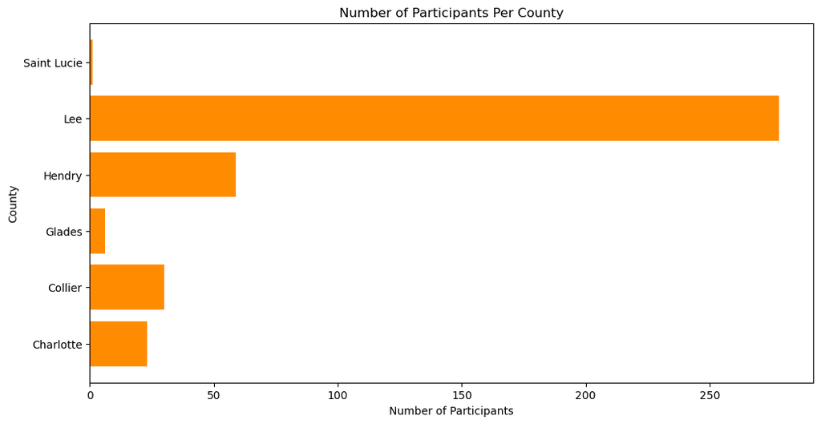

```python
# Analyzing the number of participants per county
participants_per_county = df.groupby('site_county')['participants_total'].sum()

# Display the number of participants per county
participants_per_county
# Importing necessary libraries for visualization
import matplotlib.pyplot as plt

# Creating a bar chart for the number of participants per county
plt.figure(figsize=(12, 6))
plt.barh(participants_per_county.index, participants_per_county.values, color='darkorange')
plt.xlabel('Number of Participants')
plt.ylabel('County')
plt.title('Number of Participants Per County')
plt.show()
```

# Summary of Analysis

Introduction

The dataset under consideration provides a detailed account of participants involved in various programs across different counties in Florida. The data includes demographic information such as age, race, ethnicity, and the counties where these programs are conducted. This analysis aims to provide insights into the age distribution, racial diversity, ethnic diversity, and county-wise participation in these programs.

Ethnicity Distribution

In terms of ethnicity, the majority of the participants are Hispanic. However, there is a considerable number of participants who identify as non-Hispanic. This suggests that the programs are not only ethnically inclusive but also culturally sensitive, catering to a diverse set of audiences.

Conclusion

The demographic analysis of participants in various programs across Florida reveals a diverse and inclusive environment. The programs attract a wide range of age groups, are racially diverse, and are sensitive to different ethnic backgrounds. However, there is room for improvement in counties with lower participation rates, which may benefit from more targeted outreach and program offerings.